# Laporan Mahamami Bisnis — My sample book

[figure not shown]

# Prediksi Curah Hujan Menggunakan Metode Pembelajaran Mesin Berdasarkan Data Historis Selama 20 Tahun

Curah hujan merupakan salah satu komponen penting dalam sistem iklim yang berdampak signifikan pada kehidupan manusia, ekosistem, dan berbagai sektor ekonomi. Informasi akurat tentang pola curah hujan sangat dibutuhkan, terutama untuk perencanaan sektor pertanian, pengelolaan sumber daya air, mitigasi bencana banjir, dan keberlanjutan lingkungan. Ketidakpastian dalam distribusi curah hujan, terutama akibat perubahan iklim global, menimbulkan tantangan besar bagi pengambilan keputusan yang efektif di berbagai sektor tersebut.

Kemajuan teknologi dalam pengumpulan data dan pengembangan model prediktif berbasis kecerdasan buatan (AI) dan pembelajaran mesin (ML) menawarkan solusi potensial untuk memperkirakan curah hujan dengan tingkat akurasi yang lebih tinggi. Pemanfaatan data historis seperti suhu, kelembapan, tekanan atmosfer, arah dan kecepatan angin, serta data spasial dan temporal lainnya memungkinkan pengembangan model prediksi yang lebih kompleks dan dapat diandalkan.

## Tujuan:

Tujuan utama dari pengembangan model prediksi curah hujan adalah:

1. Meningkatkan akurasi prediksi untuk mendukung pengambilan keputusan.
2. Memitigasi dampak bencana hidrometeorologi seperti banjir dan kekeringan.
3. Mendukung keberlanjutan sektor pertanian dan pengelolaan sumber daya air.
4. Memberikan wawasan yang lebih mendalam terhadap dinamika iklim regional dan global.

## Rumusan Masalah:

1. Bagaimana membangun model prediksi curah hujan yang akurat dengan memanfaatkan data meteorologi historis dan teknologi kecerdasan buatan?
2. Apa saja faktor meteorologi yang paling signifikan memengaruhi curah hujan, dan bagaimana hubungan antara faktor-faktor tersebut dapat dimodelkan?

```python
import numpy as np
import pandas as pd
import matplotlib.pyplot as plt
from sklearn.model_selection import train_test_split
from sklearn.preprocessing import MinMaxScaler
from sklearn.linear_model import LinearRegression
from sklearn.metrics import mean_squared_error
```

```python
from google.colab import drive
drive.mount('/content/drive')
```

```python
import pandas as pd
from sklearn.model_selection import train_test_split

# Baca file CSV
data = pd.read_csv('/content/drive/MyDrive/psd/uas/Rainfall_data.csv')

data
```

|  | Year | Month | Day | Specific Humidity | Relative Humidity | Temperature | Precipitation |
| --- | --- | --- | --- | --- | --- | --- | --- |
| 0 | 2000 | 1 | 1 | 8.06 | 48.25 | 23.93 | 0.00 |
| 1 | 2000 | 2 | 1 | 8.73 | 50.81 | 25.83 | 0.11 |
| 2 | 2000 | 3 | 1 | 8.48 | 42.88 | 26.68 | 0.01 |
| 3 | 2000 | 4 | 1 | 13.79 | 55.69 | 22.49 | 0.02 |
| 4 | 2000 | 5 | 1 | 17.40 | 70.88 | 19.07 | 271.14 |
| ... | ... | ... | ... | ... | ... | ... | ... |
| 247 | 2020 | 8 | 1 | 20.08 | 92.31 | 5.34 | 1203.09 |
| 248 | 2020 | 9 | 1 | 19.71 | 90.12 | 9.22 | 361.30 |
| 249 | 2020 | 10 | 1 | 18.43 | 82.69 | 12.62 | 180.18 |
| 250 | 2020 | 11 | 1 | 14.83 | 76.06 | 16.95 | 0.49 |
| 251 | 2020 | 12 | 1 | 12.21 | 69.38 | 17.77 | 12.23 |

252 rows × 7 columns

```python
data.info()
```

```
<class 'pandas.core.frame.DataFrame'>
RangeIndex: 252 entries, 0 to 251
Data columns (total 7 columns):
 #   Column             Non-Null Count  Dtype
---  ------             --------------  -----
 0   Year               252 non-null    int64
 1   Month              252 non-null    int64
 2   Day                252 non-null    int64
 3   Specific Humidity  252 non-null    float64
 4   Relative Humidity  252 non-null    float64
 5   Temperature        252 non-null    float64
 6   Precipitation      252 non-null    float64
dtypes: float64(4), int64(3)
memory usage: 13.9 KB
```

```python
print("\nChecking for missing values:")
print(data.isnull().sum())
```

```
Checking for missing values:
Year                 0
Month                0
Day                  0
Specific Humidity    0
Relative Humidity    0
Temperature          0
Precipitation        0
dtype: int64
```

```python
# Menggabungkan kolom tahun, bulan, dan hari menjadi kolom 'date'
data['date'] = pd.to_datetime(data[['Year', 'Month', 'Day']])
# Menghapus kolom 'year', 'month', dan 'day'
df = data.drop(columns=['Year', 'Month', 'Day'])
print(df)
```

```
     Specific Humidity  Relative Humidity  Temperature  Precipitation  \
0                 8.06              48.25        23.93           0.00
1                 8.73              50.81        25.83           0.11
2                 8.48              42.88        26.68           0.01
3                13.79              55.69        22.49           0.02
4                17.40              70.88        19.07         271.14
..                 ...                ...          ...            ...
247              20.08              92.31         5.34        1203.09
248              19.71              90.12         9.22         361.30
249              18.43              82.69        12.62         180.18
250              14.83              76.06        16.95           0.49
251              12.21              69.38        17.77          12.23

          date
0   2000-01-01
1   2000-02-01
2   2000-03-01
3   2000-04-01
4   2000-05-01
..         ...
247 2020-08-01
248 2020-09-01
249 2020-10-01
250 2020-11-01
251 2020-12-01

[252 rows x 5 columns]
```

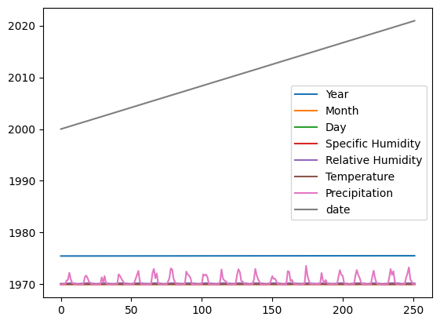

```python
data.plot()
```

```python
df.info()  # Menampilkan informasi umum mengenai DataFrame, termasuk jumlah entri, jumlah kolom, tipe data setiap kolom, dan apakah ada nilai kosong (non-null).
print('Ukuran data ', df.shape)  # Menampilkan ukuran data dalam format tuple (jumlah baris, jumlah kolom).
df.dtypes  # Menampilkan tipe data dari setiap kolom dalam DataFrame.
```

```
<class 'pandas.core.frame.DataFrame'>
RangeIndex: 252 entries, 0 to 251
Data columns (total 5 columns):
 #   Column             Non-Null Count  Dtype
---  ------             --------------  -----
 0   Specific Humidity  252 non-null    float64
 1   Relative Humidity  252 non-null    float64
 2   Temperature        252 non-null    float64
 3   Precipitation      252 non-null    float64
 4   date               252 non-null    datetime64[ns]
dtypes: datetime64[ns](1), float64(4)
memory usage: 10.0 KB
Ukuran data  (252, 5)
```

|  | 0 |
| --- | --- |
| Specific Humidity | float64 |
| Relative Humidity | float64 |
| Temperature | float64 |
| Precipitation | float64 |
| date | datetime64[ns] |

**dtype:** object

```
Matriks Korelasi:
                   Specific Humidity  Relative Humidity  Temperature  \
Specific Humidity           1.000000           0.914306    -0.905867
Relative Humidity           0.914306           1.000000    -0.950889
Temperature                -0.905867          -0.950889     1.000000
Precipitation               0.724540           0.743112    -0.779399

                   Precipitation
Specific Humidity       0.724540
Relative Humidity       0.743112
Temperature            -0.779399
Precipitation           1.000000
```

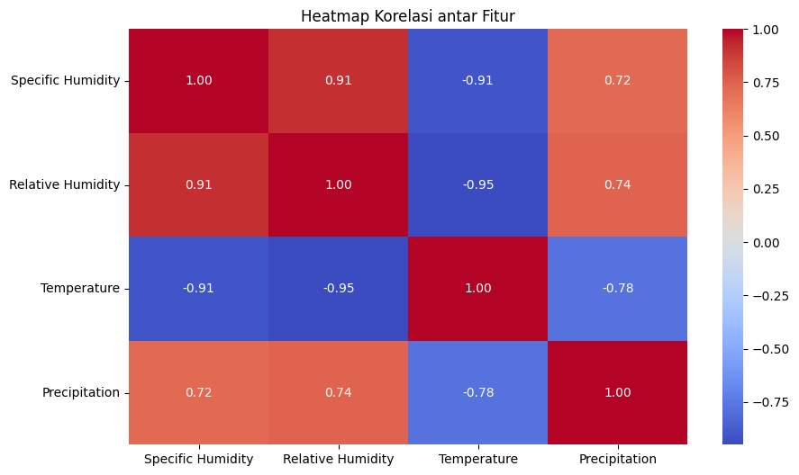

```python
import seaborn as sns
# Menghitung korelasi antar fitur untuk subset yang diinginkan
features = df[['Specific Humidity', 'Relative Humidity', 'Temperature', 'Precipitation']]
correlation_matrix = features.corr()

# Menampilkan matriks korelasi
print("Matriks Korelasi:")
print(correlation_matrix)

# Menggambar heatmap untuk visualisasi korelasi
plt.figure(figsize=(10, 6))
plt.title("Heatmap Korelasi antar Fitur")
sns.heatmap(correlation_matrix, annot=True, cmap='coolwarm', fmt=".2f")
plt.show()
```

```python
# Deskripsi Statistik
df.describe()
```

|  | Specific Humidity | Relative Humidity | Temperature | Precipitation | date |
| --- | --- | --- | --- | --- | --- |
| count | 252.000000 | 252.000000 | 252.000000 | 252.000000 | 252 |
| mean | 14.416746 | 67.259524 | 16.317262 | 206.798929 | 2010-06-16 14:17:08.571428608 |
| min | 5.740000 | 34.690000 | 4.730000 | 0.000000 | 2000-01-01 00:00:00 |
| 25% | 10.010000 | 51.845000 | 10.865000 | 0.402500 | 2005-03-24 06:00:00 |
| 50% | 15.200000 | 66.655000 | 16.915000 | 11.495000 | 2010-06-16 00:00:00 |
| 75% | 18.875000 | 84.610000 | 22.115000 | 353.200000 | 2015-09-08 12:00:00 |
| max | 20.570000 | 92.310000 | 29.340000 | 1307.430000 | 2020-12-01 00:00:00 |
| std | 4.382599 | 17.307101 | 6.584842 | 318.093091 | NaN |

```python
# Fungsi untuk membuat sliding windows
def create_sliding_windows(data, window_size):
    X, y = [], []
    for i in range(len(data) - window_size):
        X.append(data[i:i + window_size])
        y.append(data[i + window_size])
    return np.array(X), np.array(y)

# Menyiapkan data untuk sliding windows
window_size = 3  # Ukuran window
data_values = df[['Temperature', 'Precipitation']].values  # Menggunakan kolom 'Close' dan 'High' untuk prediksi
X, y = create_sliding_windows(data_values, window_size)

# Membuat DataFrame untuk hasil sliding windows
sliding_window_df = pd.DataFrame(X.reshape(X.shape[0], -1), columns=[f'Temperature_t-{window_size-i}' for i in range(window_size)] + [f'Precipitation_t-{window_size-i}' for i in range(window_size)])
sliding_window_df['Target_Temperature_t'] = y[:, 0]  # Target Close
sliding_window_df['Target_Precipitation_t'] = y[:, 1]  # Target High

# Menampilkan hasil sliding windows
print(sliding_window_df.head())
```

```
   Temperature_t-3  Temperature_t-2  Temperature_t-1  Precipitation_t-3  \
0            23.93             0.00            25.83               0.11
1            25.83             0.11            26.68               0.01
2            26.68             0.01            22.49               0.02
3            22.49             0.02            19.07             271.14
4            19.07           271.14             7.91             313.67

   Precipitation_t-2  Precipitation_t-1  Target_Temperature_t  \
0              26.68               0.01                 22.49
1              22.49               0.02                 19.07
2              19.07             271.14                  7.91
3               7.91             313.67                  6.67
4               6.67             820.45                  7.07

   Target_Precipitation_t
0                    0.02
1                  271.14
2                  313.67
3                  820.45
4                  362.38
```

```
   Temperature_t-3  Temperature_t-2  Temperature_t-1  Precipitation_t-3  \
0         0.780171         0.000000         0.857375           0.000084
1         0.857375         0.000084         0.891914           0.000008
2         0.891914         0.000008         0.721658           0.000015
3         0.721658         0.000015         0.582690           0.207384
4         0.582690         0.207384         0.129216           0.239913

   Precipitation_t-2  Precipitation_t-1  Target_Temperature_t  \
0           0.891914           0.000008              0.721658
1           0.721658           0.000015              0.582690
2           0.582690           0.207384              0.129216
3           0.129216           0.239913              0.078830
4           0.078830           0.627529              0.095083

   Target_Precipitation_t
```

[output cut: 137 more lines]

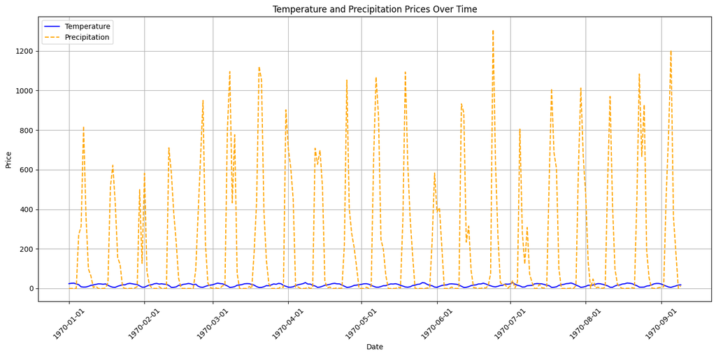

```python
# Inisialisasi scaler untuk fitur (input) dan target (output)
scaler_features = MinMaxScaler()
scaler_target = MinMaxScaler()

# Normalisasi fitur (Temperature_t-3, Temperature_t-2, Temperature_t-1, High_t-3, High_t-2, High_t-1)
df_features_normalized = pd.DataFrame(
    scaler_features.fit_transform(sliding_window_df.iloc[:, :-2]),  # Ambil semua kolom kecuali target
    columns=sliding_window_df.columns[:-2],  # Nama kolom tanpa target
    index=sliding_window_df.index
)

# Normalisasi target (Target_Temperature_t dan Target_High_t)
df_target_normalized = pd.DataFrame(
    scaler_target.fit_transform(sliding_window_df[['Target_Temperature_t', 'Target_Precipitation_t']]),
    columns=['Target_Temperature_t', 'Target_Precipitation_t'],
    index=sliding_window_df.index
)

# Gabungkan kembali dataframe yang sudah dinormalisasi
df_normalized = pd.concat([df_features_normalized, df_target_normalized], axis=1)

# Menampilkan hasil normalisasi
print(df_normalized.head())

# Mengatur fitur (X) dan target (y)
X = df_normalized[['Temperature_t-3', 'Temperature_t-2', 'Temperature_t-1', 'Precipitation_t-3', 'Precipitation_t-2', 'Precipitation_t-1']]
y = df_normalized[['Target_Temperature_t', 'Target_Precipitation_t']]  # Target adalah harga yang dinormalisasi

# Membagi data menjadi training dan testing (80% training, 20% testing)
X_train, X_test, y_train, y_test = train_test_split(X, y, test_size=0.2, shuffle=False)

print('===== Data Train =====')
print(X_train)

print('===== Data Testing ====')
print(X_test)

# Mengambil nilai tanggal dari indeks X_train dan X_test
dates_train = X_train.index
dates_test = X_test.index

import matplotlib.dates as mdates
import matplotlib.pyplot as plt

# Plot data Temperature dan Precipitation dengan format tanggal di sumbu x
plt.figure(figsize=(14, 7))

# Plot Temperature
plt.plot(df.index, df['Temperature'], label='Temperature', linestyle='-', color='blue')

# Plot Precipitation
plt.plot(df.index, df['Precipitation'], label='Precipitation', linestyle='--', color='orange')

# Format sumbu x agar menampilkan tanggal
plt.gca().xaxis.set_major_formatter(mdates.DateFormatter('%Y-%m-%d'))
plt.gca().xaxis.set_major_locator(mdates.MonthLocator())  # Menampilkan label tanggal per bulan

plt.title('Temperature and Precipitation Prices Over Time')
plt.xlabel('Date')
plt.ylabel('Price')
plt.legend(loc='upper left')
plt.grid(True)
plt.xticks(rotation=45)  # Putar label tanggal agar tidak tumpang tindih
plt.tight_layout()
plt.show()
```

```
Mean Squared Error: 0.01563442393301825
```

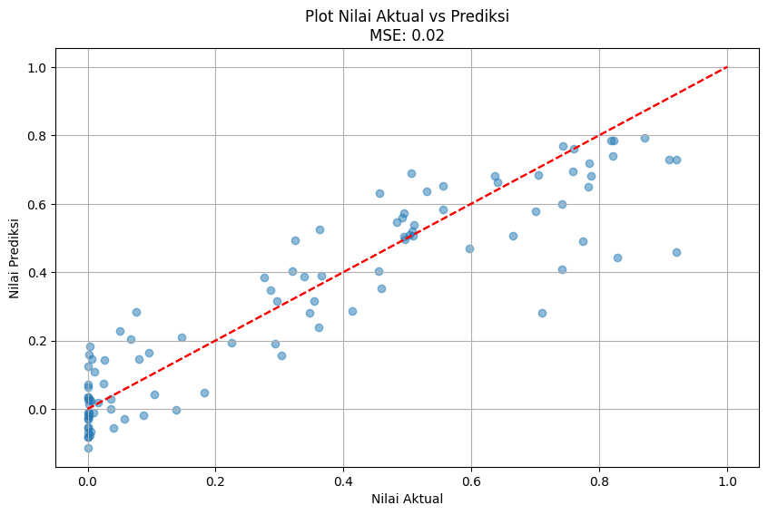

```python
# Membuat model regresi linier
model = LinearRegression()
model.fit(X_train, y_train)

# Memprediksi harga menggunakan model
y_pred = model.predict(X_test)

# Menghitung Mean Squared Error
mse = mean_squared_error(y_test, y_pred)
print(f'Mean Squared Error: {mse}')

# Membuat plot
plt.figure(figsize=(10, 6))
plt.scatter(y_test, y_pred, alpha=0.5)
plt.plot([y.min(), y.max()], [y.min(), y.max()], 'r--')  # Garis identitas
plt.xlabel('Nilai Aktual')
plt.ylabel('Nilai Prediksi')
plt.title(f'Plot Nilai Aktual vs Prediksi\nMSE: {mse:.2f}')
plt.grid()
plt.show()
```

```
Mean Squared Error (Random Forest): 0.014918466794948824
```

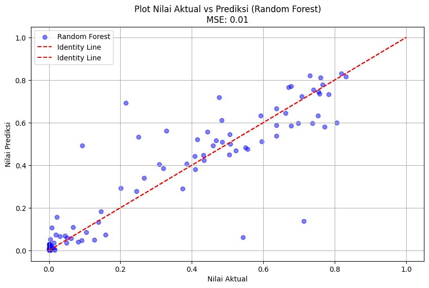

```python
from sklearn.ensemble import RandomForestRegressor
from sklearn.model_selection import train_test_split
import matplotlib.pyplot as plt
from sklearn.metrics import mean_squared_error

# Misalkan dataset kamu punya fitur X dan target y
X_train, X_test, y_train, y_test = train_test_split(X, y, test_size=0.2, random_state=42)

# Membuat model Random Forest
rf_model = RandomForestRegressor(random_state=42)
rf_model.fit(X_train, y_train)

# Memprediksi harga menggunakan Random Forest
rf_y_pred = rf_model.predict(X_test)

# Menghitung Mean Squared Error untuk Random Forest
rf_mse = mean_squared_error(y_test, rf_y_pred)
print(f'Mean Squared Error (Random Forest): {rf_mse}')

# Membuat plot untuk perbandingan hanya Random Forest
plt.figure(figsize=(10, 6))
plt.scatter(y_test, rf_y_pred, alpha=0.5, label='Random Forest', color='blue')
plt.plot([y.min(), y.max()], [y.min(), y.max()], 'r--', label='Identity Line')  # Garis identitas
plt.xlabel('Nilai Aktual')
plt.ylabel('Nilai Prediksi')
plt.title(f'Plot Nilai Aktual vs Prediksi (Random Forest)\nMSE: {rf_mse:.2f}')
plt.legend()
plt.grid()
plt.show()
```